# Task1

Jin Chen

9/13/2020

```r
library(tidyverse)
library(readxl)
library(skimr)

library(data.table)
library(ggmosaic)
```

```r
QVI_behaviour <- read_csv("../data/QVI_purchase_behaviour.csv")
QVI_transact <- read_xlsx("../data/QVI_transaction_data.xlsx")
```

```r
str(QVI_transact)
```

```
## tibble [264,836 x 8] (S3: tbl_df/tbl/data.frame)
##  $ DATE          : num [1:264836] 43390 43599 43605 43329 43330 ...
##  $ STORE_NBR     : num [1:264836] 1 1 1 2 2 4 4 4 5 7 ...
##  $ LYLTY_CARD_NBR: num [1:264836] 1000 1307 1343 2373 2426 ...
##  $ TXN_ID        : num [1:264836] 1 348 383 974 1038 ...
##  $ PROD_NBR      : num [1:264836] 5 66 61 69 108 57 16 24 42 52 ...
##  $ PROD_NAME     : chr [1:264836] "Natural Chip        Compny SeaSalt175g" "CCs Nacho Cheese    175g" "Smiths Crinkle Cut  Chips Chicken 170g" "Smiths Chip Thinly  S/Cream&Onion 175g" ...
##  $ PROD_QTY      : num [1:264836] 2 3 2 5 3 1 1 1 1 2 ...
##  $ TOT_SALES     : num [1:264836] 6 6.3 2.9 15 13.8 5.1 5.7 3.6 3.9 7.2 ...
```

```r
QVI_transact <- QVI_transact %>%
  mutate(DATE = as.Date(DATE, origin = "1899-12-30"))
```

```r
summary(QVI_transact$PROD_NAME)
```

```
##    Length     Class      Mode
##    264836 character character
```

```r
QVI_transact %>%
  select(PROD_NAME) %>%
  head(10)
```

```
## # A tibble: 10 x 1
##    PROD_NAME
##    <chr>
##  1 Natural Chip        Compny SeaSalt175g
##  2 CCs Nacho Cheese    175g
##  3 Smiths Crinkle Cut  Chips Chicken 170g
##  4 Smiths Chip Thinly  S/Cream&Onion 175g
##  5 Kettle Tortilla ChpsHny&Jlpno Chili 150g
##  6 Old El Paso Salsa   Dip Tomato Mild 300g
##  7 Smiths Crinkle Chips Salt & Vinegar 330g
##  8 Grain Waves         Sweet Chilli 210g
##  9 Doritos Corn Chip Mexican Jalapeno 150g
## 10 Grain Waves Sour    Cream&Chives 210G
```

```r
#### Examine the words in PROD_NAME to see if there are any incorrect entries
#### such as products that are not chips
productWords <- data.table(unlist(strsplit(unique(QVI_transact$PROD_NAME), "
")))
setnames(productWords, 'words')
```

```r
#### Removing digits
productWords <- productWords %>%
  mutate(words = str_replace_all(words, "[:digit:]", " "))

#### Removing special characters
productWords <- productWords %>%
  mutate(words = str_replace_all(words, "[[:punct:]]", " "))

productWords <- productWords %>%
  mutate(words = str_replace_all(words, " [gG]", " ")) #replace the g and G for grams, but only if there is a space before it

#### Let's look at the most common words by counting the number of times a word appears and
#### sorting them by this frequency in order of highest to lowest frequency

sepWords <- productWords %>%
  select(words) %>%
  str_split(" ")
freqWords <- table(unlist(sepWords))
freqWords <- as.data.frame(freqWords)
freqWords %>%
  arrange(desc(Freq))
```

```
##                Var1 Freq
## 1                    606
## 2                ",  112
## 3             Chips   21
## 4           "Smiths   15
## 5           Crinkle   14
## 6               Cut   14
## 7           "Kettle   13
## 8            Cheese   12
## 9              Salt   11
## 10         Original   10
## 11         "Doritos    9
## 12             Chip    9
## 13            Salsa    9
## 14        "Pringles    8
```

[output cut: 197 more lines]

There are salsa products in the dataset but we are only interested in the chips category, so let’s remove these.

```r
#### Remove salsa products
QVI_transact <- QVI_transact %>%
  filter(!str_detect(tolower(PROD_NAME), "salsa"))

# check that salsa products are removed
QVI_transact %>%
  filter(str_detect(tolower(PROD_NAME), "salsa"))
```

```
## # A tibble: 0 x 8
## # ... with 8 variables: DATE <date>, STORE_NBR <dbl>, LYLTY_CARD_NBR <dbl>,
## #   TXN_ID <dbl>, PROD_NBR <dbl>, PROD_NAME <chr>, PROD_QTY <dbl>,
## #   TOT_SALES <dbl>
```

Next, we can use `summary()` to check summary statistics such as mean, min and max values for each feature to see if there are any obvious outliers in the data and if there are any nulls in any of the columns (`NA's : number of nulls` will appear in the output if there are any nulls).

```r
#### Summarise the data to check for nulls and possible outliers
# Over to you!

summary(QVI_transact)
```

```
##       DATE              STORE_NBR     LYLTY_CARD_NBR        TXN_ID
##  Min.   :2018-07-01   Min.   :  1.0   Min.   :   1000   Min.   :      1
##  1st Qu.:2018-09-30   1st Qu.: 70.0   1st Qu.:  70015   1st Qu.:  67569
##  Median :2018-12-30   Median :130.0   Median : 130367   Median : 135183
##  Mean   :2018-12-30   Mean   :135.1   Mean   : 135531   Mean   : 135131
##  3rd Qu.:2019-03-31   3rd Qu.:203.0   3rd Qu.: 203084   3rd Qu.: 202654
##  Max.   :2019-06-30   Max.   :272.0   Max.   :2373711   Max.   :2415841
##     PROD_NBR       PROD_NAME            PROD_QTY         TOT_SALES
##  Min.   :  1.00   Length:246742      Min.   :  1.000   Min.   :  1.700
##  1st Qu.: 26.00   Class :character   1st Qu.:  2.000   1st Qu.:  5.800
##  Median : 53.00   Mode  :character   Median :  2.000   Median :  7.400
##  Mean   : 56.35                      Mean   :  1.908   Mean   :  7.321
##  3rd Qu.: 87.00                      3rd Qu.:  2.000   3rd Qu.:  8.800
##  Max.   :114.00                      Max.   :200.000   Max.   :650.000
```

There are no nulls in the columns but product quantity appears to have an outlier which we should investigate further. Let’s investigate further the case where 200 packets of chips are bought in one transaction.

```r
#### Filter the dataset to find the outlier
# Over to you! Use a filter to examine the transactions in question.
QVI_transact %>%
  filter(PROD_QTY == 200)
```

```
## # A tibble: 2 x 8
##   DATE       STORE_NBR LYLTY_CARD_NBR TXN_ID PROD_NBR PROD_NAME PROD_QTY
##   <date>         <dbl>          <dbl>  <dbl>    <dbl> <chr>        <dbl>
## 1 2018-08-19       226         226000 226201        4 Dorito C~      200
## 2 2019-05-20       226         226000 226210        4 Dorito C~      200
## # ... with 1 more variable: TOT_SALES <dbl>
```

```r
#### Let's see if the customer has had other transactions
# Over to you! Use a filter to see what other transactions that customer made.
QVI_transact %>%
  filter(LYLTY_CARD_NBR == 226000)
```

```
## # A tibble: 2 x 8
##   DATE       STORE_NBR LYLTY_CARD_NBR TXN_ID PROD_NBR PROD_NAME PROD_QTY
##   <date>         <dbl>          <dbl>  <dbl>    <dbl> <chr>        <dbl>
## 1 2018-08-19       226         226000 226201        4 Dorito C~      200
## 2 2019-05-20       226         226000 226210        4 Dorito C~      200
## # ... with 1 more variable: TOT_SALES <dbl>
```

It looks like this customer has only had the two transactions over the year and is not an ordinary retail customer. The customer might be buying chips for commercial purposes instead. We’ll remove this loyalty card number from further analysis.

```r
#### Filter out the customer based on the loyalty card number
# Over to you!
QVI_transact <- QVI_transact %>%
  filter(LYLTY_CARD_NBR != 226000)

#### Re-examine transaction data
# Over to you!
summary(QVI_transact)
```

```
##       DATE              STORE_NBR     LYLTY_CARD_NBR        TXN_ID
##  Min.   :2018-07-01   Min.   :  1.0   Min.   :   1000   Min.   :      1
##  1st Qu.:2018-09-30   1st Qu.: 70.0   1st Qu.:  70015   1st Qu.:  67569
##  Median :2018-12-30   Median :130.0   Median : 130367   Median : 135182
##  Mean   :2018-12-30   Mean   :135.1   Mean   : 135530   Mean   : 135130
##  3rd Qu.:2019-03-31   3rd Qu.:203.0   3rd Qu.: 203083   3rd Qu.: 202652
##  Max.   :2019-06-30   Max.   :272.0   Max.   :2373711   Max.   :2415841
##     PROD_NBR       PROD_NAME            PROD_QTY       TOT_SALES
##  Min.   :  1.00   Length:246740      Min.   :1.000   Min.   : 1.700
##  1st Qu.: 26.00   Class :character   1st Qu.:2.000   1st Qu.: 5.800
##  Median : 53.00   Mode  :character   Median :2.000   Median : 7.400
##  Mean   : 56.35                      Mean   :1.906   Mean   : 7.316
##  3rd Qu.: 87.00                      3rd Qu.:2.000   3rd Qu.: 8.800
##  Max.   :114.00                      Max.   :5.000   Max.   :29.500
```

That’s better. Now, let’s look at the number of transaction lines over time to see if there are any obvious data issues such as missing data.

```r
#### Count the number of transactions by date
# Over to you! Create a summary of transaction count by date.
QVI_transact %>%
  group_by(DATE) %>%
  summarize(count = n())
```

```
## # A tibble: 364 x 2
##    DATE       count
##    <date>     <int>
##  1 2018-07-01   663
##  2 2018-07-02   650
##  3 2018-07-03   674
##  4 2018-07-04   669
##  5 2018-07-05   660
##  6 2018-07-06   711
##  7 2018-07-07   695
##  8 2018-07-08   653
##  9 2018-07-09   692
## 10 2018-07-10   650
## # ... with 354 more rows
```

There’s only 364 rows, meaning only 364 dates which indicates a missing date. Let’s create a sequence of dates from 1 Jul 2018 to 30 Jun 2019 and use this to create a chart of number of transactions over time to find the missing date.

```r
#### Create a sequence of dates and join this the count of transactions by date
# Over to you - create a column of dates that includes every day from 1 Jul 2018 to 30 Jun 2019, and join it onto the data to fill in the missing day.
seqDates <- data.frame("DATE" = seq(from = as.Date("2018-07-01"), to = as.Date("2019-06-30"), by = 'day'))

transactions_by_day <- QVI_transact %>%
  group_by(DATE) %>%
  summarize(count = n()) %>%
  right_join(seqDates) %>%
  arrange(DATE)
transactions_by_day
```

```
## # A tibble: 365 x 2
##    DATE       count
##    <date>     <int>
##  1 2018-07-01   663
##  2 2018-07-02   650
##  3 2018-07-03   674
##  4 2018-07-04   669
##  5 2018-07-05   660
##  6 2018-07-06   711
##  7 2018-07-07   695
##  8 2018-07-08   653
##  9 2018-07-09   692
## 10 2018-07-10   650
## # ... with 355 more rows
```

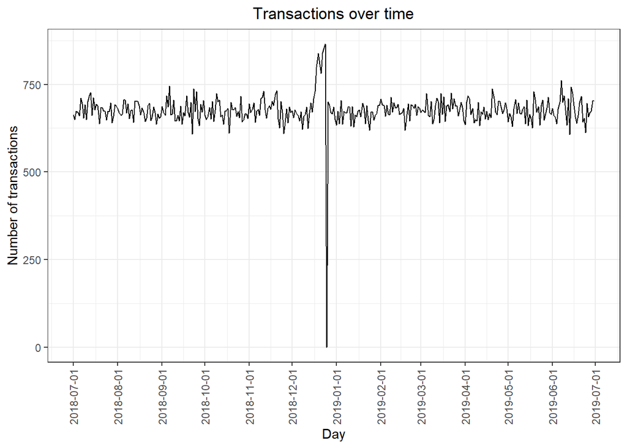

```r
#set NA to 0
transactions_by_day <- transactions_by_day %>%
  mutate(count = replace_na(count, 0))

#### Setting plot themes to format graphs
theme_set(theme_bw())
theme_update(plot.title = element_text(hjust = 0.5))
#### Plot transactions over time
ggplot(transactions_by_day, aes(x = DATE, y = count)) +
 geom_line() +
 labs(x = "Day", y = "Number of transactions", title = "Transactions over time") +
 scale_x_date(breaks = "1 month") +
 theme(axis.text.x = element_text(angle = 90, vjust = 0.5))
```

We can see that there is an increase in purchases in December and a break in late December. Let’s zoom in on this.

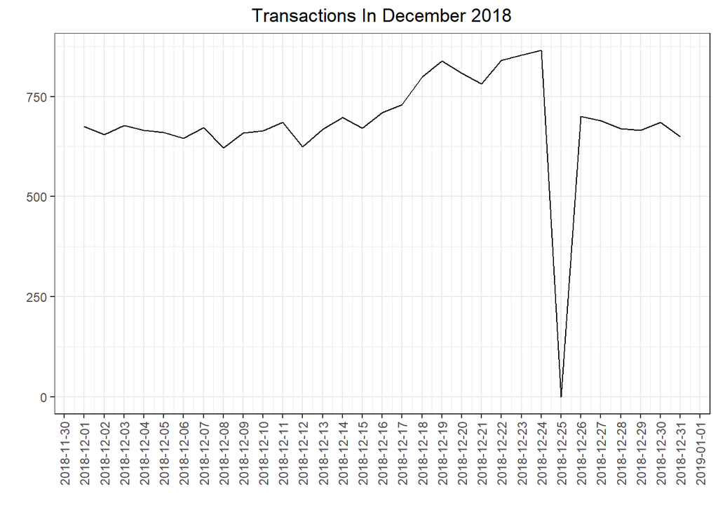

```r
#### Filter to December and look at individual days
# Over to you - recreate the chart above zoomed in to the relevant dates.

transactions_december18 <- transactions_by_day %>%
  filter(DATE >= "2018-12-01" & DATE <= "2018-12-31")

ggplot(transactions_december18, aes(x = DATE, y = count)) +
 geom_line() +
 labs(x = " ", y = " ", title = "Transactions In December 2018") +
 scale_x_date(breaks = "day") +
 theme(axis.text.x = element_text(angle = 90, vjust = 0.5))
```

We can see that the increase in sales occurs in the lead-up to Christmas and that there are zero sales on Christmas day itself. This is due to shops being closed on Christmas day.

Now that we are satisfied that the data no longer has outliers, we can move on to creating other features such as brand of chips or pack size from PROD_NAME. We will start with pack size.

```r
#### Pack size
#### We can work this out by taking the digits that are in PROD_NAME

QVI_transact <- QVI_transact %>%
  mutate(PACK_SIZE = as.integer(str_extract(PROD_NAME, "\\d+")))


#### Always check your output
#### Let's check if the pack sizes look sensible
QVI_transact %>%
  select(PACK_SIZE) %>%
  arrange(desc(PACK_SIZE))
```

```
## # A tibble: 246,740 x 1
##    PACK_SIZE
##        <int>
##  1       380
##  2       380
##  3       380
##  4       380
##  5       380
##  6       380
##  7       380
##  8       380
##  9       380
## 10       380
## # ... with 246,730 more rows
```

The largest size is 380g and the smallest size is 70g - seems sensible!

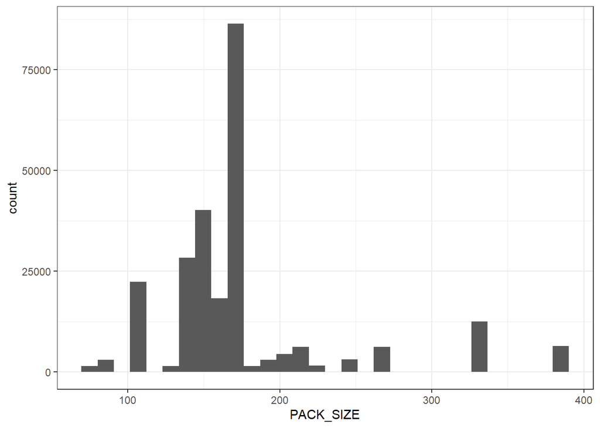

```r
#### Let's plot a histogram of PACK_SIZE since we know that it is a categorical variable and not a continuous variable even though it is numeric.
# Over to you! Plot a histogram showing the number of transactions by pack size.

QVI_transact %>%
  group_by(PACK_SIZE) %>%
  ggplot(aes(x = PACK_SIZE)) +
  geom_histogram()
```

Pack sizes created look reasonable. Now to create brands, we can use the first word in PROD_NAME to work out the brand name

```r
#### Brands
# Over to you! Create a column which contains the brand of the product, by extracting it from the product name.
QVI_transact <- QVI_transact %>%
  mutate(Brand = word(QVI_transact$PROD_NAME, 1, 1))


#### Checking brands
# Over to you! Check the results look reasonable.
QVI_transact %>%
  select(Brand) %>%
  count(Brand, sort = TRUE) %>%
  head(10)
```

```
## # A tibble: 10 x 2
##    Brand         n
##    <chr>     <int>
##  1 Kettle    41288
##  2 Smiths    27390
##  3 Pringles  25102
##  4 Doritos   22041
##  5 Thins     14075
##  6 RRD       11894
##  7 Infuzions 11057
##  8 WW        10320
##  9 Cobs       9693
## 10 Tostitos   9471
```

Some of the brand names look like they are of the same brands - such as RED and RRD, which are both Red Rock Deli chips. Let’s combine these together.

```r
#### Clean brand names
# Over to you! Add any additional brand adjustments you think may be required.
QVI_transact <- QVI_transact %>%
  mutate(Brand = case_when(Brand == "Red" ~ "RRD",
                           Brand == "SNBTS" ~ "Sunbites",
                           Brand == "Snbts" ~ "Sunbites",
                           Brand == "INFZNS" ~ "Infuzions",
                           Brand == "Infzns" ~ "Infuzions",
                           Brand == "WW" ~ "Woolworths",
                           Brand == "WOOLWORTHS" ~ "Woolworths",
                           Brand == "SMITH" ~ "Smiths",
                           Brand == "Smith" ~ "Smiths",
                           Brand == "NCC" ~ "Natural",
                           Brand == "NATURAL" ~ "Natural",
                           Brand == "Dorito" ~ "Doritos",
                           Brand == "Grain" ~ "GrnWves",
                           Brand == "GRNWVES" ~ "GrnWves",
                           TRUE ~ Brand))
#### Check again
# Over to you! Check the results look reasonable.
QVI_transact %>%
  distinct(Brand) %>%
  arrange(Brand)
```

```
## # A tibble: 20 x 1
##    Brand
##    <chr>
##  1 Burger
##  2 CCs
##  3 Cheetos
##  4 Cheezels
##  5 Cobs
##  6 Doritos
##  7 French
##  8 GrnWves
##  9 Infuzions
## 10 Kettle
## 11 Natural
## 12 Pringles
## 13 RRD
## 14 Smiths
## 15 Sunbites
## 16 Thins
## 17 Tostitos
## 18 Twisties
## 19 Tyrrells
## 20 Woolworths
```

### Examining customer data

```r
#### Examining customer data
# Over to you! Do some basic summaries of the dataset, including distributions of any key columns.
skim(QVI_transact)
```

Data summary

| Name | QVI_transact |
| --- | --- |
| Number of rows | 246740 |
| Number of columns | 10 |
| _______________________ |  |
| Column type frequency: |  |
| character | 2 |
| Date | 1 |
| numeric | 7 |
| ________________________ |  |
| Group variables | None |

**Variable type: character**

| skim_variable | n_missing | complete_rate | min | max | empty | n_unique | whitespace |
| --- | --- | --- | --- | --- | --- | --- | --- |
| PROD_NAME | 0 | 1 | 17 | 40 | 0 | 105 | 0 |
| Brand | 0 | 1 | 3 | 10 | 0 | 20 | 0 |

**Variable type: Date**

| skim_variable | n_missing | complete_rate | min | max | median | n_unique |
| --- | --- | --- | --- | --- | --- | --- |
| DATE | 0 | 1 | 2018-07-01 | 2019-06-30 | 2018-12-30 | 364 |

**Variable type: numeric**

| skim_variable | n_missing | complete_rate | mean | sd | p0 | p25 | p50 | p75 | p100 | hist |
| --- | --- | --- | --- | --- | --- | --- | --- | --- | --- | --- |
| STORE_NBR | 0 | 1 | 135.05 | 76.79 | 1.0 | 70.00 | 130.0 | 203.0 | 272.0 | ▆▇▇▇▇ |
| LYLTY_CARD_NBR | 0 | 1 | 135530.25 | 80715.20 | 1000.0 | 70015.00 | 130367.0 | 203083.2 | 2373711.0 | ▇▁▁▁▁ |
| TXN_ID | 0 | 1 | 135130.36 | 78147.60 | 1.0 | 67568.75 | 135181.5 | 202652.2 | 2415841.0 | ▇▁▁▁▁ |
| PROD_NBR | 0 | 1 | 56.35 | 33.70 | 1.0 | 26.00 | 53.0 | 87.0 | 114.0 | ▇▇▆▇▇ |
| PROD_QTY | 0 | 1 | 1.91 | 0.34 | 1.0 | 2.00 | 2.0 | 2.0 | 5.0 | ▁▇▁▁▁ |
| TOT_SALES | 0 | 1 | 7.32 | 2.47 | 1.7 | 5.80 | 7.4 | 8.8 | 29.5 | ▆▇▁▁▁ |
| PACK_SIZE | 0 | 1 | 175.58 | 59.43 | 70.0 | 150.00 | 170.0 | 175.0 | 380.0 | ▁▇▁▁▁ |

```r
#### Merge transaction data to customer data
data <- merge(QVI_transact, QVI_behaviour, all.x = TRUE)
```

As the number of rows in `data` is the same as that of `transactionData`, we can be sure that no duplicates were created. This is because we created `data` by setting `all.x = TRUE` (in other words, a left join) which means take all the rows in `transactionData` and find rows with matching values in shared columns and then joining the details in these rows to the `x` or the first mentioned table.

Let’s also check if some customers were not matched on by checking for nulls.

```r
# Over to you! See if any transactions did not have a matched customer.
data %>%
  filter_all(any_vars(is.na(.)))
```

```
##  [1] LYLTY_CARD_NBR   DATE             STORE_NBR        TXN_ID
##  [5] PROD_NBR         PROD_NAME        PROD_QTY         TOT_SALES
##  [9] PACK_SIZE        Brand            LIFESTAGE        PREMIUM_CUSTOMER
## <0 rows> (or 0-length row.names)
```

```r
#apply(data, 2, function(x) any(is.na(x)))
```

Great, there are no nulls! So all our customers in the transaction data has been accounted for in the customer dataset. Note that if you are continuing with Task 2, you may want to retain this dataset which you can write out as a csv

```r
#fwrite(data, paste0(filePath,"QVI_data.csv"))
write_csv(data, path = "QVI_data.csv")
```

Data exploration is now complete! ## Data analysis on customer segments Now that the data is ready for analysis, we can define some metrics of interest to the client: Who spends the most on chips (total sales), describing customers by lifestage and how premium their general purchasing behaviour is - How many customers are in each segment - How many chips are bought per customer by segment - What’s the average chip price by customer segment

We could also ask our data team for more information. Examples are: - The customer’s total spend over the period and total spend for each transaction to understand what proportion of their grocery spend is on chips - Proportion of customers in each customer segment overall to compare against the mix of customers who purchase chips

Let’s start with calculating total sales by LIFESTAGE and PREMIUM_CUSTOMER and plotting the split by these segments to describe which customer segment contribute most to chip sales.

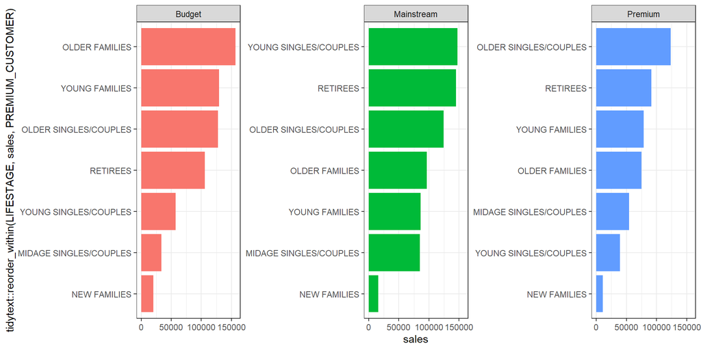

```r
#### Total sales by LIFESTAGE and PREMIUM_CUSTOMER
# Over to you! Calculate the summary of sales by those dimensions and create a plot.

Total_sales <- data %>%
  group_by(LIFESTAGE, PREMIUM_CUSTOMER) %>%
  summarize(sales = sum(TOT_SALES)) %>%
  arrange(desc(sales))
Total_sales %>%
  ggplot(aes(x = tidytext::reorder_within(LIFESTAGE, sales, PREMIUM_CUSTOMER), y = sales, fill = PREMIUM_CUSTOMER)) +
  geom_histogram(stat = "identity", show.legend = FALSE) +
  facet_wrap(~PREMIUM_CUSTOMER, scales = "free_y") +
  coord_flip() +
  tidytext::scale_x_reordered()
```

Higher sales may also be driven by more units of chips being bought per customer.

Let’s have a look at this next.

```r
#### Average number of units per customer by LIFESTAGE and PREMIUM_CUSTOMER
# Over to you! Calculate and plot the average number of units per customer by those two dimensions.
```